# Visualization Multivariate Data

Juan Carlos Martinez Ovando

29 March 2017

# Introduction

The ability to generate synthetic data with a specified correlation structure is essential to modeling work.

As you might expect, `R`s toolbox of packages and functions for generating and visualizing data from multivariate distributions is impressive. The basic function for generating multivariate normal data is `mvrnorm()` from the MASS package included in base R, although the mvtnorm package also provides functions for simulating both multivariate normal and t distributions. (For tutorial on how to use R to simulate from multivariate normal distributions from first principles using some linear algebra and the Cholesky decomposition see the astrostatistics tutorial on Multivariate Computations.)

The following block of code generates 5,000 draws from a bivariate normal distribution with mean (0,0) and covariance matrix Sigma printed in code. The function `kde2d()`, also from the Mass package generates a two-dimensional kernel density estimation of the distribution’s probability density function.

[SIMULATING MULTIVARIATE DATA](https://stat.ethz.ch/pipermail/r-help/2003-September/038314.html)

Lets first simulate a bivariate normal sample:

```r
library(MASS)

# Simulate bivariate normal data
mu <- c(0,0)                         # Mean
Sigma <- matrix(c(1, .5, .5, 1), 2)  # Covariance matrix
Sigma
```

```
##      [,1] [,2]
## [1,]  1.0  0.5
## [2,]  0.5  1.0
```

```r
# Generate sample from N(mu, Sigma)
bivn <- mvrnorm(5000, mu = mu, Sigma = Sigma )  # from Mass package
head(bivn)
```

```
##            [,1]        [,2]
## [1,]  1.1815049  0.40322931
## [2,] -0.8438600  0.05500322
## [3,]  0.7843892 -0.14957486
## [4,] -0.9468936 -1.00771138
## [5,]  0.0733645  0.40274112
## [6,]  0.6873219  1.46674273
```

Calculate kernel density estimate

```r
bivn.kde <- kde2d(bivn[,1], bivn[,2], n = 50)   # from MASS package
```

`R` offers several ways of visualizing the distribution. These next two lines of code overlay a contour plot on a “heat Map” that maps the density of points to a gradient of colors.

Contour plot overlayed on heat map image of results:

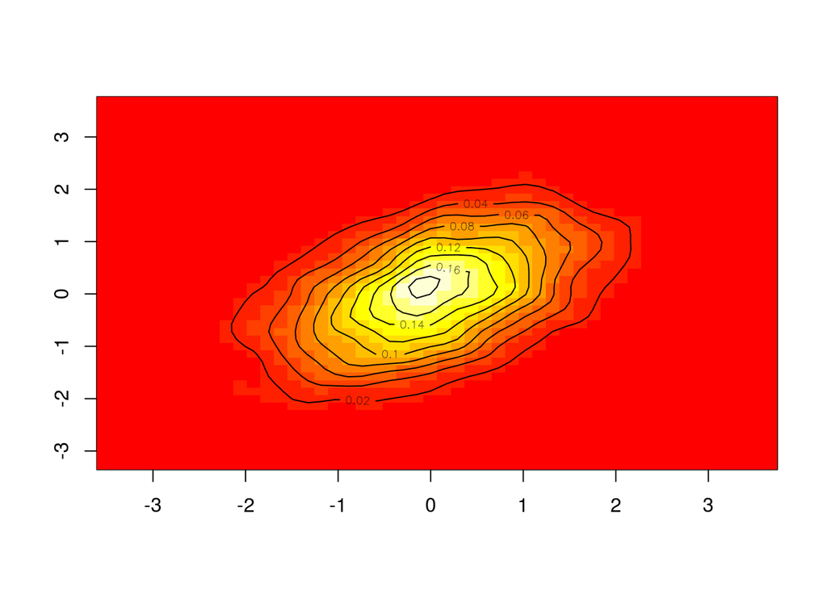

```r
image(bivn.kde)                     # from base graphics package
contour(bivn.kde, add = TRUE)       # from base graphics package
```